# Optimal Treatment Analysis

## Outcome Variable

**Outcome Variable:** ever_wasted

## Predictor Variables

**Intervention Variable:** mbmi

**Adjustment Set:**

- arm
- W_mage
- meducyrs
- feducyrs
- single
- brthmon
- W_parity
- delta_W_mage
- delta_meducyrs
- delta_feducyrs
- delta_single
- delta_brthmon
- delta_W_parity

## Stratifying Variables

The analysis was stratified on these variable(s):

- agecat
- studyid
- country

## Data Summary

| agecat | studyid | country | mbmi | ever_wasted | n_cell | n |
| --- | --- | --- | --- | --- | --- | --- |
| 0-24 months | ki0047075b-MAL-ED | BANGLADESH | Normal weight | 0 | 154 | 254 |
| 0-24 months | ki0047075b-MAL-ED | BANGLADESH | Normal weight | 1 | 68 | 254 |
| 0-24 months | ki0047075b-MAL-ED | BANGLADESH | Underweight | 0 | 15 | 254 |
| 0-24 months | ki0047075b-MAL-ED | BANGLADESH | Underweight | 1 | 17 | 254 |
| 0-24 months | ki0047075b-MAL-ED | BRAZIL | Normal weight | 0 | 194 | 221 |
| 0-24 months | ki0047075b-MAL-ED | BRAZIL | Normal weight | 1 | 17 | 221 |
| 0-24 months | ki0047075b-MAL-ED | BRAZIL | Underweight | 0 | 8 | 221 |
| 0-24 months | ki0047075b-MAL-ED | BRAZIL | Underweight | 1 | 2 | 221 |
| 0-24 months | ki0047075b-MAL-ED | INDIA | Normal weight | 0 | 107 | 242 |
| 0-24 months | ki0047075b-MAL-ED | INDIA | Normal weight | 1 | 86 | 242 |
| 0-24 months | ki0047075b-MAL-ED | INDIA | Underweight | 0 | 20 | 242 |
| 0-24 months | ki0047075b-MAL-ED | INDIA | Underweight | 1 | 29 | 242 |
| 0-24 months | ki0047075b-MAL-ED | NEPAL | Normal weight | 0 | 169 | 238 |
| 0-24 months | ki0047075b-MAL-ED | NEPAL | Normal weight | 1 | 69 | 238 |
| 0-24 months | ki0047075b-MAL-ED | NEPAL | Underweight | 0 | 0 | 238 |
| 0-24 months | ki0047075b-MAL-ED | NEPAL | Underweight | 1 | 0 | 238 |
| 0-24 months | ki0047075b-MAL-ED | PERU | Normal weight | 0 | 261 | 290 |
| 0-24 months | ki0047075b-MAL-ED | PERU | Normal weight | 1 | 24 | 290 |
| 0-24 months | ki0047075b-MAL-ED | PERU | Underweight | 0 | 3 | 290 |
| 0-24 months | ki0047075b-MAL-ED | PERU | Underweight | 1 | 2 | 290 |
| 0-24 months | ki0047075b-MAL-ED | SOUTH AFRICA | Normal weight | 0 | 207 | 270 |
| 0-24 months | ki0047075b-MAL-ED | SOUTH AFRICA | Normal weight | 1 | 55 | 270 |
| 0-24 months | ki0047075b-MAL-ED | SOUTH AFRICA | Underweight | 0 | 8 | 270 |
| 0-24 months | ki0047075b-MAL-ED | SOUTH AFRICA | Underweight | 1 | 0 | 270 |
| 0-24 months | ki0047075b-MAL-ED | TANZANIA, UNITED REPUBLIC OF | Normal weight | 0 | 214 | 256 |
| 0-24 months | ki0047075b-MAL-ED | TANZANIA, UNITED REPUBLIC OF | Normal weight | 1 | 28 | 256 |
| 0-24 months | ki0047075b-MAL-ED | TANZANIA, UNITED REPUBLIC OF | Underweight | 0 | 10 | 256 |
| 0-24 months | ki0047075b-MAL-ED | TANZANIA, UNITED REPUBLIC OF | Underweight | 1 | 4 | 256 |
| 0-24 months | ki1000304b-SAS-CompFeed | INDIA | Normal weight | 0 | 210 | 410 |
| 0-24 months | ki1000304b-SAS-CompFeed | INDIA | Normal weight | 1 | 91 | 410 |

[output cut: 158 more lines]

The following strata were considered:

- agecat: 0-24 months, studyid: ki0047075b-MAL-ED, country: BANGLADESH
- agecat: 0-24 months, studyid: ki0047075b-MAL-ED, country: BRAZIL
- agecat: 0-24 months, studyid: ki0047075b-MAL-ED, country: INDIA
- agecat: 0-24 months, studyid: ki0047075b-MAL-ED, country: NEPAL
- agecat: 0-24 months, studyid: ki0047075b-MAL-ED, country: PERU
- agecat: 0-24 months, studyid: ki0047075b-MAL-ED, country: SOUTH AFRICA
- agecat: 0-24 months, studyid: ki0047075b-MAL-ED, country: TANZANIA, UNITED REPUBLIC OF
- agecat: 0-24 months, studyid: ki1000304b-SAS-CompFeed, country: INDIA
- agecat: 0-24 months, studyid: ki1017093-NIH-Birth, country: BANGLADESH
- agecat: 0-24 months, studyid: ki1017093b-PROVIDE, country: BANGLADESH
- agecat: 0-24 months, studyid: ki1017093c-NIH-Crypto, country: BANGLADESH
- agecat: 0-24 months, studyid: ki1066203-TanzaniaChild2, country: TANZANIA, UNITED REPUBLIC OF
- agecat: 0-24 months, studyid: ki1112895-iLiNS-Zinc, country: BURKINA FASO
- agecat: 0-24 months, studyid: ki1119695-PROBIT, country: BELARUS
- agecat: 0-24 months, studyid: ki1126311-ZVITAMBO, country: ZIMBABWE
- agecat: 0-24 months, studyid: ki1148112-LCNI-5, country: MALAWI
- agecat: 0-6 months, studyid: ki0047075b-MAL-ED, country: BANGLADESH
- agecat: 0-6 months, studyid: ki0047075b-MAL-ED, country: BRAZIL
- agecat: 0-6 months, studyid: ki0047075b-MAL-ED, country: INDIA
- agecat: 0-6 months, studyid: ki0047075b-MAL-ED, country: NEPAL
- agecat: 0-6 months, studyid: ki0047075b-MAL-ED, country: PERU
- agecat: 0-6 months, studyid: ki0047075b-MAL-ED, country: SOUTH AFRICA
- agecat: 0-6 months, studyid: ki0047075b-MAL-ED, country: TANZANIA, UNITED REPUBLIC OF
- agecat: 0-6 months, studyid: ki1000304b-SAS-CompFeed, country: INDIA
- agecat: 0-6 months, studyid: ki1017093-NIH-Birth, country: BANGLADESH
- agecat: 0-6 months, studyid: ki1017093b-PROVIDE, country: BANGLADESH
- agecat: 0-6 months, studyid: ki1017093c-NIH-Crypto, country: BANGLADESH
- agecat: 0-6 months, studyid: ki1066203-TanzaniaChild2, country: TANZANIA, UNITED REPUBLIC OF
- agecat: 0-6 months, studyid: ki1119695-PROBIT, country: BELARUS
- agecat: 0-6 months, studyid: ki1126311-ZVITAMBO, country: ZIMBABWE
- agecat: 0-6 months, studyid: ki1148112-LCNI-5, country: MALAWI
- agecat: 6-24 months, studyid: ki0047075b-MAL-ED, country: BANGLADESH
- agecat: 6-24 months, studyid: ki0047075b-MAL-ED, country: BRAZIL
- agecat: 6-24 months, studyid: ki0047075b-MAL-ED, country: INDIA
- agecat: 6-24 months, studyid: ki0047075b-MAL-ED, country: NEPAL
- agecat: 6-24 months, studyid: ki0047075b-MAL-ED, country: PERU
- agecat: 6-24 months, studyid: ki0047075b-MAL-ED, country: SOUTH AFRICA
- agecat: 6-24 months, studyid: ki0047075b-MAL-ED, country: TANZANIA, UNITED REPUBLIC OF
- agecat: 6-24 months, studyid: ki1000304b-SAS-CompFeed, country: INDIA
- agecat: 6-24 months, studyid: ki1017093-NIH-Birth, country: BANGLADESH
- agecat: 6-24 months, studyid: ki1017093b-PROVIDE, country: BANGLADESH
- agecat: 6-24 months, studyid: ki1017093c-NIH-Crypto, country: BANGLADESH
- agecat: 6-24 months, studyid: ki1066203-TanzaniaChild2, country: TANZANIA, UNITED REPUBLIC OF
- agecat: 6-24 months, studyid: ki1112895-iLiNS-Zinc, country: BURKINA FASO
- agecat: 6-24 months, studyid: ki1119695-PROBIT, country: BELARUS
- agecat: 6-24 months, studyid: ki1126311-ZVITAMBO, country: ZIMBABWE
- agecat: 6-24 months, studyid: ki1148112-LCNI-5, country: MALAWI

### Dropped Strata

Some strata were dropped due to rare outcomes:

- agecat: 0-24 months, studyid: ki0047075b-MAL-ED, country: BRAZIL
- agecat: 0-24 months, studyid: ki0047075b-MAL-ED, country: NEPAL
- agecat: 0-24 months, studyid: ki0047075b-MAL-ED, country: PERU
- agecat: 0-24 months, studyid: ki0047075b-MAL-ED, country: SOUTH AFRICA
- agecat: 0-24 months, studyid: ki0047075b-MAL-ED, country: TANZANIA, UNITED REPUBLIC OF
- agecat: 0-6 months, studyid: ki0047075b-MAL-ED, country: BRAZIL
- agecat: 0-6 months, studyid: ki0047075b-MAL-ED, country: NEPAL
- agecat: 0-6 months, studyid: ki0047075b-MAL-ED, country: PERU
- agecat: 0-6 months, studyid: ki0047075b-MAL-ED, country: SOUTH AFRICA
- agecat: 0-6 months, studyid: ki0047075b-MAL-ED, country: TANZANIA, UNITED REPUBLIC OF
- agecat: 0-6 months, studyid: ki1148112-LCNI-5, country: MALAWI
- agecat: 6-24 months, studyid: ki0047075b-MAL-ED, country: BRAZIL
- agecat: 6-24 months, studyid: ki0047075b-MAL-ED, country: NEPAL
- agecat: 6-24 months, studyid: ki0047075b-MAL-ED, country: PERU
- agecat: 6-24 months, studyid: ki0047075b-MAL-ED, country: SOUTH AFRICA
- agecat: 6-24 months, studyid: ki0047075b-MAL-ED, country: TANZANIA, UNITED REPUBLIC OF
- agecat: 6-24 months, studyid: ki1119695-PROBIT, country: BELARUS

## Methods Detail

We’re interested in the causal parameters $E[Y_a]$ for all values of $a \in \mathcal{A}$. These parameters represent the mean outcome if, possibly contrary to fact, we intervened to set all units to have $A=a$. Under the randomization and positivity assumptions, these are identified by the statistical parameters $\psi_a=E_W[E_{Y|A,W}(Y|A=a,W)]$. In addition, we’re interested in the mean of $Y$, $E[Y]$ under no intervention (the observed mean). We will estimate these parameters by using SuperLearner to fit the relevant likelihood factors – $E_{Y|A,W}(Y|A=a,W)$ and $p(A=a|W)$, and then updating our likelihood fit using a joint TMLE.

For unadjusted analyses ($W=\{\}$), initial likelihoods were estimated using Lrnr_glm to estimate the simple $E(Y|A)$ and Lrnr_mean to estimate $p(A)$. For adjusted analyses, a small library containing Lrnr_glmnet, Lrnr_xgboost, and Lrnr_mean was used.

Having estimated these parameters, we will then use the delta method to estimate relative risks and attributable risks relative to a prespecified baseline level of $A$.

# Results Detail

## Results Plots

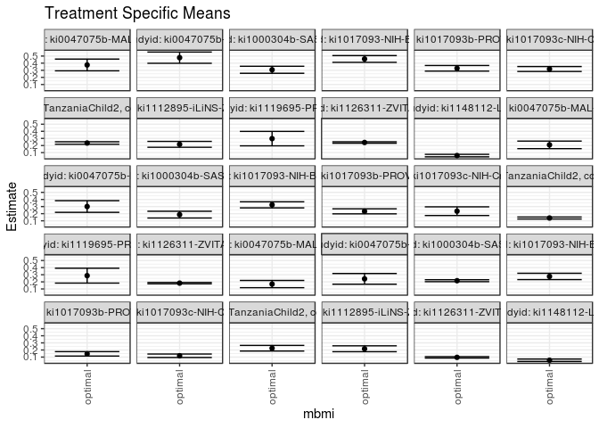

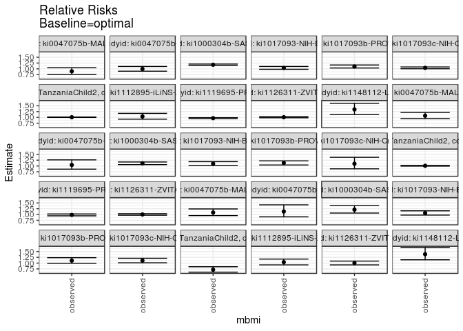

## Results Table

### Parameter: TSM

| agecat | studyid | country | intervention_level | baseline_level | estimate | ci_lower | ci_upper |
| --- | --- | --- | --- | --- | --- | --- | --- |
| 0-24 months | ki0047075b-MAL-ED | BANGLADESH | optimal | NA | 0.3749062 | 0.2924268 | 0.4573856 |
| 0-24 months | ki0047075b-MAL-ED | INDIA | optimal | NA | 0.4775699 | 0.3985532 | 0.5565866 |
| 0-24 months | ki1000304b-SAS-CompFeed | INDIA | optimal | NA | 0.3071321 | 0.2573813 | 0.3568830 |
| 0-24 months | ki1017093-NIH-Birth | BANGLADESH | optimal | NA | 0.4593559 | 0.4118646 | 0.5068473 |
| 0-24 months | ki1017093b-PROVIDE | BANGLADESH | optimal | NA | 0.3277052 | 0.2877821 | 0.3676282 |
| 0-24 months | ki1017093c-NIH-Crypto | BANGLADESH | optimal | NA | 0.3178368 | 0.2828333 | 0.3528403 |
| 0-24 months | ki1066203-TanzaniaChild2 | TANZANIA, UNITED REPUBLIC OF | optimal | NA | 0.2354526 | 0.2179607 | 0.2529444 |
| 0-24 months | ki1112895-iLiNS-Zinc | BURKINA FASO | optimal | NA | 0.2170346 | 0.1756712 | 0.2583981 |
| 0-24 months | ki1119695-PROBIT | BELARUS | optimal | NA | 0.2971007 | 0.1954778 | 0.3987237 |
| 0-24 months | ki1126311-ZVITAMBO | ZIMBABWE | optimal | NA | 0.2430399 | 0.2325778 | 0.2535019 |
| 0-24 months | ki1148112-LCNI-5 | MALAWI | optimal | NA | 0.0586512 | 0.0412085 | 0.0760939 |
| 0-6 months | ki0047075b-MAL-ED | BANGLADESH | optimal | NA | 0.2094145 | 0.1564373 | 0.2623918 |
| 0-6 months | ki0047075b-MAL-ED | INDIA | optimal | NA | 0.3009097 | 0.2189386 | 0.3828807 |
| 0-6 months | ki1000304b-SAS-CompFeed | INDIA | optimal | NA | 0.1865131 | 0.1390776 | 0.2339487 |
| 0-6 months | ki1017093-NIH-Birth | BANGLADESH | optimal | NA | 0.3246889 | 0.2817693 | 0.3676086 |
| 0-6 months | ki1017093b-PROVIDE | BANGLADESH | optimal | NA | 0.2332198 | 0.1974129 | 0.2690268 |
| 0-6 months | ki1017093c-NIH-Crypto | BANGLADESH | optimal | NA | 0.2354456 | 0.1743524 | 0.2965389 |
| 0-6 months | ki1066203-TanzaniaChild2 | TANZANIA, UNITED REPUBLIC OF | optimal | NA | 0.1391464 | 0.1248932 | 0.1533997 |
| 0-6 months | ki1119695-PROBIT | BELARUS | optimal | NA | 0.2870821 | 0.1823246 | 0.3918396 |
| 0-6 months | ki1126311-ZVITAMBO | ZIMBABWE | optimal | NA | 0.1819491 | 0.1722944 | 0.1916038 |
| 6-24 months | ki0047075b-MAL-ED | BANGLADESH | optimal | NA | 0.1684436 | 0.1174754 | 0.2194118 |
| 6-24 months | ki0047075b-MAL-ED | INDIA | optimal | NA | 0.2420331 | 0.1666776 | 0.3173886 |
| 6-24 months | ki1000304b-SAS-CompFeed | INDIA | optimal | NA | 0.2159893 | 0.2023678 | 0.2296108 |
| 6-24 months | ki1017093-NIH-Birth | BANGLADESH | optimal | NA | 0.2760984 | 0.2317116 | 0.3204852 |
| 6-24 months | ki1017093b-PROVIDE | BANGLADESH | optimal | NA | 0.1456237 | 0.1145052 | 0.1767421 |
| 6-24 months | ki1017093c-NIH-Crypto | BANGLADESH | optimal | NA | 0.1188167 | 0.0941760 | 0.1434575 |
| 6-24 months | ki1066203-TanzaniaChild2 | TANZANIA, UNITED REPUBLIC OF | optimal | NA | 0.2249640 | 0.1851814 | 0.2647465 |
| 6-24 months | ki1112895-iLiNS-Zinc | BURKINA FASO | optimal | NA | 0.2170346 | 0.1756712 | 0.2583981 |
| 6-24 months | ki1126311-ZVITAMBO | ZIMBABWE | optimal | NA | 0.0963710 | 0.0863333 | 0.1064088 |
| 6-24 months | ki1148112-LCNI-5 | MALAWI | optimal | NA | 0.0553166 | 0.0382093 | 0.0724238 |

### Parameter: E(Y)

| agecat | studyid | country | intervention_level | baseline_level | estimate | ci_lower | ci_upper |
| --- | --- | --- | --- | --- | --- | --- | --- |
| 0-24 months | ki0047075b-MAL-ED | BANGLADESH | observed | NA | 0.3346457 | 0.2765014 | 0.3927899 |
| 0-24 months | ki0047075b-MAL-ED | INDIA | observed | NA | 0.4752066 | 0.4121581 | 0.5382551 |
| 0-24 months | ki1000304b-SAS-CompFeed | INDIA | observed | NA | 0.3609756 | 0.2943508 | 0.4276005 |
| 0-24 months | ki1017093-NIH-Birth | BANGLADESH | observed | NA | 0.4775641 | 0.4383415 | 0.5167867 |
| 0-24 months | ki1017093b-PROVIDE | BANGLADESH | observed | NA | 0.3602392 | 0.3238339 | 0.3966444 |
| 0-24 months | ki1017093c-NIH-Crypto | BANGLADESH | observed | NA | 0.3311258 | 0.2975342 | 0.3647175 |
| 0-24 months | ki1066203-TanzaniaChild2 | TANZANIA, UNITED REPUBLIC OF | observed | NA | 0.2371002 | 0.2198828 | 0.2543177 |
| 0-24 months | ki1112895-iLiNS-Zinc | BURKINA FASO | observed | NA | 0.2259307 | 0.1907517 | 0.2611097 |
| 0-24 months | ki1119695-PROBIT | BELARUS | observed | NA | 0.2875710 | 0.1859343 | 0.3892076 |
| 0-24 months | ki1126311-ZVITAMBO | ZIMBABWE | observed | NA | 0.2450750 | 0.2365573 | 0.2535928 |
| 0-24 months | ki1148112-LCNI-5 | MALAWI | observed | NA | 0.0788530 | 0.0605839 | 0.0971222 |
| 0-6 months | ki0047075b-MAL-ED | BANGLADESH | observed | NA | 0.2244094 | 0.1730022 | 0.2758167 |
| 0-6 months | ki0047075b-MAL-ED | INDIA | observed | NA | 0.3140496 | 0.2554513 | 0.3726479 |
| 0-6 months | ki1000304b-SAS-CompFeed | INDIA | observed | NA | 0.2078240 | 0.1493922 | 0.2662557 |
| 0-6 months | ki1017093-NIH-Birth | BANGLADESH | observed | NA | 0.3569132 | 0.3192325 | 0.3945938 |
| 0-6 months | ki1017093b-PROVIDE | BANGLADESH | observed | NA | 0.2630792 | 0.2296894 | 0.2964690 |
| 0-6 months | ki1017093c-NIH-Crypto | BANGLADESH | observed | NA | 0.2582781 | 0.2270370 | 0.2895193 |
| 0-6 months | ki1066203-TanzaniaChild2 | TANZANIA, UNITED REPUBLIC OF | observed | NA | 0.1402985 | 0.1262390 | 0.1543580 |
| 0-6 months | ki1119695-PROBIT | BELARUS | observed | NA | 0.2823424 | 0.1800585 | 0.3846263 |
| 0-6 months | ki1126311-ZVITAMBO | ZIMBABWE | observed | NA | 0.1824982 | 0.1748345 | 0.1901620 |
| 6-24 months | ki0047075b-MAL-ED | BANGLADESH | observed | NA | 0.1833333 | 0.1342773 | 0.2323893 |
| 6-24 months | ki0047075b-MAL-ED | INDIA | observed | NA | 0.2735043 | 0.2162683 | 0.3307402 |
| 6-24 months | ki1000304b-SAS-CompFeed | INDIA | observed | NA | 0.2617801 | 0.2144185 | 0.3091417 |
| 6-24 months | ki1017093-NIH-Birth | BANGLADESH | observed | NA | 0.2939002 | 0.2554778 | 0.3323226 |
| 6-24 months | ki1017093b-PROVIDE | BANGLADESH | observed | NA | 0.1612378 | 0.1321259 | 0.1903497 |
| 6-24 months | ki1017093c-NIH-Crypto | BANGLADESH | observed | NA | 0.1315068 | 0.1069744 | 0.1560393 |
| 6-24 months | ki1066203-TanzaniaChild2 | TANZANIA, UNITED REPUBLIC OF | observed | NA | 0.1612576 | 0.1450216 | 0.1774936 |
| 6-24 months | ki1112895-iLiNS-Zinc | BURKINA FASO | observed | NA | 0.2259307 | 0.1907517 | 0.2611097 |
| 6-24 months | ki1126311-ZVITAMBO | ZIMBABWE | observed | NA | 0.0965066 | 0.0902505 | 0.1027627 |
| 6-24 months | ki1148112-LCNI-5 | MALAWI | observed | NA | 0.0765492 | 0.0583736 | 0.0947248 |

### Parameter: RR

| agecat | studyid | country | intervention_level | baseline_level | estimate | ci_lower | ci_upper |
| --- | --- | --- | --- | --- | --- | --- | --- |
| 0-24 months | ki0047075b-MAL-ED | BANGLADESH | observed | optimal | 0.8926117 | 0.7594546 | 1.0491156 |
| 0-24 months | ki0047075b-MAL-ED | INDIA | observed | optimal | 0.9950514 | 0.8989123 | 1.1014726 |
| 0-24 months | ki1000304b-SAS-CompFeed | INDIA | observed | optimal | 1.1753105 | 1.1457230 | 1.2056620 |
| 0-24 months | ki1017093-NIH-Birth | BANGLADESH | observed | optimal | 1.0396384 | 0.9808834 | 1.1019129 |
| 0-24 months | ki1017093b-PROVIDE | BANGLADESH | observed | optimal | 1.0992782 | 1.0363714 | 1.1660034 |
| 0-24 months | ki1017093c-NIH-Crypto | BANGLADESH | observed | optimal | 1.0418108 | 1.0039359 | 1.0811146 |
| 0-24 months | ki1066203-TanzaniaChild2 | TANZANIA, UNITED REPUBLIC OF | observed | optimal | 1.0069978 | 0.9961844 | 1.0179287 |
| 0-24 months | ki1112895-iLiNS-Zinc | BURKINA FASO | observed | optimal | 1.0409890 | 0.9232653 | 1.1737235 |
| 0-24 months | ki1119695-PROBIT | BELARUS | observed | optimal | 0.9679241 | 0.9474375 | 0.9888536 |
| 0-24 months | ki1126311-ZVITAMBO | ZIMBABWE | observed | optimal | 1.0083737 | 0.9838096 | 1.0335512 |
| 0-24 months | ki1148112-LCNI-5 | MALAWI | observed | optimal | 1.3444400 | 1.1230063 | 1.6095358 |
| 0-6 months | ki0047075b-MAL-ED | BANGLADESH | observed | optimal | 1.0716039 | 0.9457983 | 1.2141436 |
| 0-6 months | ki0047075b-MAL-ED | INDIA | observed | optimal | 1.0436673 | 0.8620505 | 1.2635472 |
| 0-6 months | ki1000304b-SAS-CompFeed | INDIA | observed | optimal | 1.1142592 | 1.0594217 | 1.1719352 |
| 0-6 months | ki1017093-NIH-Birth | BANGLADESH | observed | optimal | 1.0992465 | 1.0185168 | 1.1863751 |
| 0-6 months | ki1017093b-PROVIDE | BANGLADESH | observed | optimal | 1.1280312 | 1.0435658 | 1.2193331 |
| 0-6 months | ki1017093c-NIH-Crypto | BANGLADESH | observed | optimal | 1.0969758 | 0.8759018 | 1.3738480 |
| 0-6 months | ki1066203-TanzaniaChild2 | TANZANIA, UNITED REPUBLIC OF | observed | optimal | 1.0082796 | 0.9927107 | 1.0240927 |
| 0-6 months | ki1119695-PROBIT | BELARUS | observed | optimal | 0.9834900 | 0.9437210 | 1.0249349 |
| 0-6 months | ki1126311-ZVITAMBO | ZIMBABWE | observed | optimal | 1.0030179 | 0.9716371 | 1.0354121 |
| 6-24 months | ki0047075b-MAL-ED | BANGLADESH | observed | optimal | 1.0883960 | 0.9542876 | 1.2413509 |
| 6-24 months | ki0047075b-MAL-ED | INDIA | observed | optimal | 1.1300283 | 0.8998630 | 1.4190649 |
| 6-24 months | ki1000304b-SAS-CompFeed | INDIA | observed | optimal | 1.2120051 | 1.0639083 | 1.3807170 |
| 6-24 months | ki1017093-NIH-Birth | BANGLADESH | observed | optimal | 1.0644763 | 0.9766686 | 1.1601784 |
| 6-24 months | ki1017093b-PROVIDE | BANGLADESH | observed | optimal | 1.1072222 | 0.9934195 | 1.2340616 |
| 6-24 months | ki1017093c-NIH-Crypto | BANGLADESH | observed | optimal | 1.1068040 | 1.0135803 | 1.2086020 |
| 6-24 months | ki1066203-TanzaniaChild2 | TANZANIA, UNITED REPUBLIC OF | observed | optimal | 0.7168152 | 0.6093230 | 0.8432704 |
| 6-24 months | ki1112895-iLiNS-Zinc | BURKINA FASO | observed | optimal | 1.0409890 | 0.9232653 | 1.1737235 |
| 6-24 months | ki1126311-ZVITAMBO | ZIMBABWE | observed | optimal | 1.0014068 | 0.9225409 | 1.0870147 |
| 6-24 months | ki1148112-LCNI-5 | MALAWI | observed | optimal | 1.3838389 | 1.1429250 | 1.6755344 |

### Parameter: PAR

| agecat | studyid | country | intervention_level | baseline_level | estimate | ci_lower | ci_upper |
| --- | --- | --- | --- | --- | --- | --- | --- |
| 0-24 months | ki0047075b-MAL-ED | BANGLADESH | optimal | NA | -0.0402605 | -0.1002454 | 0.0197244 |
| 0-24 months | ki0047075b-MAL-ED | INDIA | optimal | NA | -0.0023633 | -0.0508833 | 0.0461567 |
| 0-24 months | ki1000304b-SAS-CompFeed | INDIA | optimal | NA | 0.0538435 | 0.0365155 | 0.0711715 |
| 0-24 months | ki1017093-NIH-Birth | BANGLADESH | optimal | NA | 0.0182082 | -0.0084690 | 0.0448853 |
| 0-24 months | ki1017093b-PROVIDE | BANGLADESH | optimal | NA | 0.0325340 | 0.0132622 | 0.0518057 |
| 0-24 months | ki1017093c-NIH-Crypto | BANGLADESH | optimal | NA | 0.0132890 | 0.0015252 | 0.0250528 |
| 0-24 months | ki1066203-TanzaniaChild2 | TANZANIA, UNITED REPUBLIC OF | optimal | NA | 0.0016477 | -0.0008873 | 0.0041826 |
| 0-24 months | ki1112895-iLiNS-Zinc | BURKINA FASO | optimal | NA | 0.0088960 | -0.0172730 | 0.0350651 |
| 0-24 months | ki1119695-PROBIT | BELARUS | optimal | NA | -0.0095298 | -0.0148242 | -0.0042354 |
| 0-24 months | ki1126311-ZVITAMBO | ZIMBABWE | optimal | NA | 0.0020352 | -0.0039575 | 0.0080278 |
| 0-24 months | ki1148112-LCNI-5 | MALAWI | optimal | NA | 0.0202018 | 0.0087779 | 0.0316257 |
| 0-6 months | ki0047075b-MAL-ED | BANGLADESH | optimal | NA | 0.0149949 | -0.0116234 | 0.0416132 |
| 0-6 months | ki0047075b-MAL-ED | INDIA | optimal | NA | 0.0131399 | -0.0443433 | 0.0706231 |
| 0-6 months | ki1000304b-SAS-CompFeed | INDIA | optimal | NA | 0.0213108 | 0.0074641 | 0.0351576 |
| 0-6 months | ki1017093-NIH-Birth | BANGLADESH | optimal | NA | 0.0322243 | 0.0073320 | 0.0571165 |
| 0-6 months | ki1017093b-PROVIDE | BANGLADESH | optimal | NA | 0.0298594 | 0.0115824 | 0.0481364 |
| 0-6 months | ki1017093c-NIH-Crypto | BANGLADESH | optimal | NA | 0.0228325 | -0.0301246 | 0.0757897 |
| 0-6 months | ki1066203-TanzaniaChild2 | TANZANIA, UNITED REPUBLIC OF | optimal | NA | 0.0011521 | -0.0010086 | 0.0033128 |
| 0-6 months | ki1119695-PROBIT | BELARUS | optimal | NA | -0.0047397 | -0.0167254 | 0.0072460 |
| 0-6 months | ki1126311-ZVITAMBO | ZIMBABWE | optimal | NA | 0.0005491 | -0.0052341 | 0.0063323 |
| 6-24 months | ki0047075b-MAL-ED | BANGLADESH | optimal | NA | 0.0148897 | -0.0074661 | 0.0372456 |
| 6-24 months | ki0047075b-MAL-ED | INDIA | optimal | NA | 0.0314712 | -0.0239581 | 0.0869004 |
| 6-24 months | ki1000304b-SAS-CompFeed | INDIA | optimal | NA | 0.0457908 | 0.0095500 | 0.0820317 |
| 6-24 months | ki1017093-NIH-Birth | BANGLADESH | optimal | NA | 0.0178018 | -0.0059429 | 0.0415465 |
| 6-24 months | ki1017093b-PROVIDE | BANGLADESH | optimal | NA | 0.0156141 | -0.0003369 | 0.0315651 |
| 6-24 months | ki1017093c-NIH-Crypto | BANGLADESH | optimal | NA | 0.0126901 | 0.0020038 | 0.0233764 |
| 6-24 months | ki1066203-TanzaniaChild2 | TANZANIA, UNITED REPUBLIC OF | optimal | NA | -0.0637064 | -0.0997844 | -0.0276283 |
| 6-24 months | ki1112895-iLiNS-Zinc | BURKINA FASO | optimal | NA | 0.0088960 | -0.0172730 | 0.0350651 |
| 6-24 months | ki1126311-ZVITAMBO | ZIMBABWE | optimal | NA | 0.0001356 | -0.0077698 | 0.0080409 |
| 6-24 months | ki1148112-LCNI-5 | MALAWI | optimal | NA | 0.0212326 | 0.0096476 | 0.0328177 |

### Parameter: PAF

| agecat | studyid | country | intervention_level | baseline_level | estimate | ci_lower | ci_upper |
| --- | --- | --- | --- | --- | --- | --- | --- |
| 0-24 months | ki0047075b-MAL-ED | BANGLADESH | optimal | NA | -0.1203079 | -0.3167344 | 0.0468162 |
| 0-24 months | ki0047075b-MAL-ED | INDIA | optimal | NA | -0.0049732 | -0.1124556 | 0.0921245 |
| 0-24 months | ki1000304b-SAS-CompFeed | INDIA | optimal | NA | 0.1491610 | 0.1271887 | 0.1705802 |
| 0-24 months | ki1017093-NIH-Birth | BANGLADESH | optimal | NA | 0.0381271 | -0.0194892 | 0.0924873 |
| 0-24 months | ki1017093b-PROVIDE | BANGLADESH | optimal | NA | 0.0903122 | 0.0350949 | 0.1423696 |
| 0-24 months | ki1017093c-NIH-Crypto | BANGLADESH | optimal | NA | 0.0401328 | 0.0039205 | 0.0750287 |
| 0-24 months | ki1066203-TanzaniaChild2 | TANZANIA, UNITED REPUBLIC OF | optimal | NA | 0.0069492 | -0.0038302 | 0.0176129 |
| 0-24 months | ki1112895-iLiNS-Zinc | BURKINA FASO | optimal | NA | 0.0393751 | -0.0831124 | 0.1480106 |
| 0-24 months | ki1119695-PROBIT | BELARUS | optimal | NA | -0.0331389 | -0.0554786 | -0.0112720 |
| 0-24 months | ki1126311-ZVITAMBO | ZIMBABWE | optimal | NA | 0.0083042 | -0.0164569 | 0.0324621 |
| 0-24 months | ki1148112-LCNI-5 | MALAWI | optimal | NA | 0.2561959 | 0.1095331 | 0.3787028 |
| 0-6 months | ki0047075b-MAL-ED | BANGLADESH | optimal | NA | 0.0668194 | -0.0573078 | 0.1763742 |
| 0-6 months | ki0047075b-MAL-ED | INDIA | optimal | NA | 0.0418402 | -0.1600249 | 0.2085772 |
| 0-6 months | ki1000304b-SAS-CompFeed | INDIA | optimal | NA | 0.1025427 | 0.0560888 | 0.1467105 |
| 0-6 months | ki1017093-NIH-Birth | BANGLADESH | optimal | NA | 0.0902860 | 0.0181801 | 0.1570963 |
| 0-6 months | ki1017093b-PROVIDE | BANGLADESH | optimal | NA | 0.1134997 | 0.0417470 | 0.1798796 |
| 0-6 months | ki1017093c-NIH-Crypto | BANGLADESH | optimal | NA | 0.0884029 | -0.1416805 | 0.2721174 |
| 0-6 months | ki1066203-TanzaniaChild2 | TANZANIA, UNITED REPUBLIC OF | optimal | NA | 0.0082116 | -0.0073428 | 0.0235259 |
| 0-6 months | ki1119695-PROBIT | BELARUS | optimal | NA | -0.0167872 | -0.0596353 | 0.0243282 |
| 0-6 months | ki1126311-ZVITAMBO | ZIMBABWE | optimal | NA | 0.0030088 | -0.0291908 | 0.0342010 |
| 6-24 months | ki0047075b-MAL-ED | BANGLADESH | optimal | NA | 0.0812167 | -0.0479021 | 0.1944260 |
| 6-24 months | ki0047075b-MAL-ED | INDIA | optimal | NA | 0.1150664 | -0.1112803 | 0.2953106 |
| 6-24 months | ki1000304b-SAS-CompFeed | INDIA | optimal | NA | 0.1749209 | 0.0600693 | 0.2757386 |
| 6-24 months | ki1017093-NIH-Birth | BANGLADESH | optimal | NA | 0.0605709 | -0.0238888 | 0.1380636 |
| 6-24 months | ki1017093b-PROVIDE | BANGLADESH | optimal | NA | 0.0968389 | -0.0066240 | 0.1896677 |
| 6-24 months | ki1017093c-NIH-Crypto | BANGLADESH | optimal | NA | 0.0964977 | 0.0133983 | 0.1725978 |
| 6-24 months | ki1066203-TanzaniaChild2 | TANZANIA, UNITED REPUBLIC OF | optimal | NA | -0.3950597 | -0.6411657 | -0.1858592 |
| 6-24 months | ki1112895-iLiNS-Zinc | BURKINA FASO | optimal | NA | 0.0393751 | -0.0831124 | 0.1480106 |
| 6-24 months | ki1126311-ZVITAMBO | ZIMBABWE | optimal | NA | 0.0014048 | -0.0839628 | 0.0800492 |
| 6-24 months | ki1148112-LCNI-5 | MALAWI | optimal | NA | 0.2773725 | 0.1250519 | 0.4031755 |